# Predicting ICU length of stay among patients with alcohol-associated liver disease

BMIN503/EPID600 Final Project

Author

Sue Hyon Kim

## 1 Overview

[This project](https://github.com/kshyon/BMIN503_Final_Project_SHK) aims to predict the ICU length of stay for patients with alcohol-associated liver disease by applying and comparing several supervised machine learning algorithms: linear regression models, random forest, and extreme gradient boosting. This study will use the Medical Information for Intensive Care (MIMIC) -IV database. I met with Dr. Serper, who contributed domain expertise from her clinical experience as a gastroenterologist, and consulted Dr. Min regarding analytic and machine learning approaches.

## 2 Introduction

The incidence of alcohol-associated liver disease (ALD) has risen globally in recent years, especially following the intensification of psychosocial stressors during the COVID-19 pandemic. Decompensated ALD is characterized by complications, such as encephalopathy, gastrointestinal bleeding, hepatopulmonary or hepatorenal syndrome, often requiring critical care.

Receiving care in the ICU generates areas of concern, because the length of stay in the ICU is associated with patient prognosis, caregiver communication, and healthcare expenses. Prolonged ICU stays have been linked to unfavorable patient outcomes, such as in-hospital mortality and ICU readmissions. Caregivers of ICU patients are also anxious to know the projected length of stay in critical care, as they have to plan for work and other commitments. Moreover, the patient’s ICU length of stay is associated with healthcare expenses and resource allocation, with losses incurring in the first three days due to intensive use of diagnostic and medical resources, and profitability beginning on day four. Predicting whether a patient’s ICU stay will exceed four days could help tailor care plans, alleviate caregiver uncertainty, and optimize resource allocation by reducing unnecessary interventions and appropriately allocated resources based on the patient’s critical care needs.

In recognition of the importance of predicting ICU length of stay, several machine learning prediction models have been developed for this purpose. However, these previous models omit the comprehensive range of factors that could project ICU length of stay from the outset, as they do not account for distinct disease traits or trajectories specific to the ALD patient population and fail to consider patient demographics, vital signs, and lab values concurrently. By integrating insights from critical care with techniques from biomedical informatics, this study aims to build machine learning models that predict ICU length of stay in relation to the four-day threshold for patients with ALD. It will consider both demographic and clinical features of the patients as predictors and the potential usefulness of the models will be evaluated based on their predictive accuracy.

## 3 Methods

The Medical Information Mart for Intensive Care (MIMIC)-IV database was used for this study. Demographic and clinical features were utilized as predictors of ICU length of stay (≧4days, <4days) across three machine learning approaches: logistic regression, random forest, and XGBoost. Initial vital signs and lab results taken after ICU admission were included, as data from the first hours reflect the acute phase of a patient’s condition and serve as early indicators of their health status. The top significant variables were also extracted to gain insights into patient subgroups for subsequent unsupervised machine learning analyses.

```r
library(readr)
library(dplyr)
library(janitor)
library(data.table)
library(stringr)
library(missForest)
library(table1)
library(ggplot2)
library(randomForest)
library(glmnet)
library(xgboost)
library(vip)
library(tidymodels)
library(broom)
```

1. **Preparing the data**

Importing data and joining tables to create the dataset with variables relevant to my project.

```r
# Import the CSV file
patients<-read_csv("C:/Users/sue94/Documents/대학원/_PhD 박사과정/3학기/MIMIC/patients.csv")
diagnoses_icd<-read_csv("C:/Users/sue94/Documents/대학원/_PhD 박사과정/3학기/MIMIC/diagnoses_icd.csv")
icu<-read_csv("C:/Users/sue94/Documents/대학원/_PhD 박사과정/3학기/MIMIC/icustays.csv")
demographics <- read_csv("C:/Users/sue94/Documents/대학원/_PhD 박사과정/3학기/MIMIC/admissions.csv")
```

```r
#join tables to screen for LT-A, predict ICU readmission / length of stay
pt_diagnosis<-left_join(patients, diagnoses_icd, by=c("subject_id"))

#filter for ALD patients
patients_ald<-pt_diagnosis|>
  filter((icd_code%in% c("5710","5711","5712")& icd_version=="9")|(icd_code%in% c("K700", "K7010", "K7011", "K702", "K7030", "K7031", "K7040", "K7041", "K709")&icd_version=="10"))

# However, some patients have multiple documentation of ALD or LT status using more than one ICD codes, so now we need a cleaned list of participants
## Patients with ALD (N = 4727)
patients_ald<-patients_ald|>
  group_by(subject_id)|>
  dplyr::slice(1)|>
  ungroup()

# are there any ALD patient who had LT?
patient_allLT <- unique(diagnoses_icd$subject_id[(diagnoses_icd$icd_code == "V427" & diagnoses_icd$icd_version == "9")|(diagnoses_icd$icd_code=="Z944" & diagnoses_icd$icd_version=="10")])
patient_LT_alc <- patients_ald |>
  filter(subject_id %in% patient_allLT)
## n=203
## they will be excluded because their ICU visits are typlically related to post-transplant care, sepsis, or other factors not comparable to those of patients with ALD.

# Patients with ALD who have not undergone LT (N=4524)
patients_ald_nonLT<-patients_ald|>
  filter((!subject_id %in% patient_LT_alc$subject_id))|>
  select(-hadm_id, -seq_num, -icd_code, -icd_version)

# ALD(non-LT) patients' ICU admission events (N=4865 ICU admissions)
## Some ALD patients who have not received LT have multiple ICU stays.
aldNonLT_icu<-left_join(patients_ald_nonLT, icu, by="subject_id")|>
  filter(!is.na(stay_id))
## Each ICU admission event will be used as an independent data point to predict its IUC length of stay

# Join demographic characteristics to each ICU admission, create new variables, and remove unnecessary variables
aldNonLT_icu<-left_join(aldNonLT_icu, demographics, by=c("subject_id", "hadm_id"))|>
  mutate(year_birth=anchor_year-anchor_age)|>
  mutate(age=as.numeric(format(intime, "%Y"))-year_birth)|>
  mutate(EDlos=if_else(!is.na(edouttime)&!is.na(edregtime), as.numeric(difftime(edouttime,edregtime, units="mins")), 0))|>
  mutate(EDvisit=factor(ifelse(!is.na(edregtime), 1, 0), levels=c(0,1), labels=c("No", "Yes")))|>
  mutate(ICUdeath=factor(case_when(is.na(deathtime)~0, intime<deathtime & deathtime<outtime~1, TRUE~0), levels=c(0,1), labels=c("No","Yes")))|>
  mutate(los_icu4=factor(ifelse(los>=4, 1, 0), levels=c(0,1), labels=c("< 4days in ICU","≧ 4days in ICU")))|>
  select(-anchor_age, -anchor_year, -anchor_year_group, -admit_provider_id, -discharge_location, -year_birth, -edregtime, -edouttime, -dod, -deathtime)
```

Joining the initial V/S and lab values from each ICU stay is next, BUT…

The csv containing V/S and lab values were too large to load directly into R (39GB). I had to extract relevant items (v/s and labs) for my population of interest (ALD patients) from the original csv file in chunks, and then save the final output as a new csv file to skip this stressful process moving forward.

```r
## Retain itemid for relevant V/S and labs
### Hgb (220228), Platelet count (227457), INR (227467), PTT (227466), Total Bilirubin (225690), Direct Bilirubin (225651), ALT (220644), AST (220587), Alb (227456), Ammonia (220580), BUN (225624), Cr (220615), Sodium-serum (220645), Sodium-whole blood (226534), Potasium-serum (227442) Potassium-whole blood (227464), Cortisol (227463) Lactate (225668), WBC count (220546), Glucose-finger stick (225664), Glucose-serum (220621), Glucose-whole blood (226537), CRP (227444), pO2_abga (220224), pCO2_abga (220235), HCO3-serum (227443), iCa (225667)
### NIBPm (220181) ABPm (220052) HR(220045) RR(220210) SpO2(220277)
relevant_itemids <- c(220228, 227457, 227467,227466,225690,225651,220644,220587,227456,220580,225624,220615,220645,226534,227442,227464,227463,225668,220546,225664,220621,226537,227444,220224,220235,227443,225667,220181, 220052, 220045, 220210, 220277)
library(data.table)
file.exists("C:/Users/sue94/Documents/대학원/_PhD 박사과정/3학기/MIMIC/chartevents.csv/chartevents.csv")

con <- file("C:/Users/sue94/Documents/대학원/_PhD 박사과정/3학기/MIMIC/chartevents.csv/chartevents.csv", "r")
chunk_size<-10000
cols_to_read <- c("subject_id", "hadm_id", "stay_id", "charttime", "itemid", "value", "valuenum", "valueuom")
header <- readLines(con, n = 1)
chunk_lines <- readLines(con, n = chunk_size)
filtered_chunks<-list()

while (length(chunk_lines) > 0) {
  temp_file <- tempfile()
  writeLines(c(header, chunk_lines), temp_file)
  chunk <- fread(temp_file, select = cols_to_read)
  filtered_chunk<-chunk[itemid %in% relevant_itemids]
  filtered_chunks <- append(filtered_chunks, list(filtered_chunk))
  chunk_lines <- readLines(con, n = chunk_size)
}

close(con)
vitalNlabs<-rbindlist(filtered_chunks)

vitalNlabs_ald<-vitalNlabs|>
  filter(subject_id%in%ALD_list$subject_id)

write.csv(vitalNlabs_ald, "C:/Users/sue94/Documents/대학원/_PhD 박사과정/3학기/MIMIC/vitalNlabs_ald.csv", row.names = FALSE)
```

Now, back to joining initial V/S and lab values from the ICU stay

```r
file.exists("C:/Users/sue94/Documents/대학원/_PhD 박사과정/3학기/MIMIC/vitalNlabs_ald.csv")
```

```
[1] TRUE
```

```r
vitalNlabs_ald<-read_csv("C:/Users/sue94/Documents/대학원/_PhD 박사과정/3학기/MIMIC/vitalNlabs_ald.csv")
```

```r
# Change the itemid into the actual v/s and lab type
vitalNlabs_ald<-vitalNlabs_ald|>
  mutate(itemid=as.character(itemid))|>
  mutate(itemid=recode(itemid, "220228"="Hgb", "227457"="PLT", "227467"="INR", "227466"="PTT", "225690"="TBil", "225651"="DirectBil", "220644"="ALT", "220587"="AST", "227456"="Alb", "220580"="Ammonia", "225624"="BUN", "220615"="Cr", "220645"="Na_serum", "226534"="Na_blood", "227442"="K_serum", "227464"="K_blood", "227463"="Cortisol", "225668"="Lactate", "220546"="WBC", "225664"="Glucose_poct", "220621"="Glucose_serum", "226537"="Glucose_blood", "227444"="CRP", "220224"="pO2_abga", "220235"="pCO2_abga", "227443"="HCO3_serum", "225667"="iCa", "220181"="NIBPm", "220052"="ABPm", "220045"="HR", "220210"="RR", "220277"="SpO2"))

# Keep only the initial v/s and lab values after ICU admission and remove unnecessary variables
## just making sure that these two columns are duplicates before removing one of them :)
all(vitalNlabs_ald$value == vitalNlabs_ald$valuenum)
```

```
[1] TRUE
```

```r
vitalNlabs_ald_initial<-vitalNlabs_ald|>
  group_by(stay_id, itemid)|>
  filter(charttime==min(charttime))|>
  ungroup()|>
  select(-charttime, -valuenum)

# This is in a long format, which complicates the left-joining process. We will convert this into a wide data frame
wide_vitalNlabs_ald_initial <-vitalNlabs_ald_initial|>
  tidyr::pivot_wider(names_from=itemid, values_from = c(value, valueuom))

# Finally joining the V/S and lab values for each ICU stay
aldNonLT_icu<-left_join(aldNonLT_icu, wide_vitalNlabs_ald_initial, by=c("subject_id", "hadm_id","stay_id"))

# Now, I have my data set of non-LT ALD patients who have been admitted to ICUs, with their demographics, each of their unique ICU stays, and initial vitalsNlabs from each unique ICU stay
head(aldNonLT_icu)
```

```
# A tibble: 6 × 87
  subject_id gender  hadm_id  stay_id first_careunit               last_careunit
       <dbl> <chr>     <dbl>    <dbl> <chr>                        <chr>
1   10002114 M      27793700 34672098 Coronary Care Unit (CCU)     Coronary Car…
2   10005606 M      29646384 38740124 Trauma SICU (TSICU)          Trauma SICU …
3   10005866 M      20364112 34170353 Surgical Intensive Care Uni… Surgical Int…
4   10006053 M      22942076 32895909 Medical Intensive Care Unit… Medical Inte…
5   10006441 M      24120560 37240744 Medical/Surgical Intensive … Medical/Surg…
6   10007795 F      28477357 31921355 Medical/Surgical Intensive … Medical/Surg…
# ℹ 81 more variables: intime <dttm>, outtime <dttm>, los <dbl>,
#   admittime <dttm>, dischtime <dttm>, admission_type <chr>,
#   admission_location <chr>, insurance <chr>, language <chr>,
#   marital_status <chr>, race <chr>, hospital_expire_flag <dbl>, age <dbl>,
#   EDlos <dbl>, EDvisit <fct>, ICUdeath <fct>, los_icu4 <fct>,
#   value_Glucose_poct <dbl>, value_RR <dbl>, value_HR <dbl>, value_SpO2 <dbl>,
#   value_ABPm <dbl>, value_NIBPm <dbl>, value_pO2_abga <dbl>, …
```

2. **Exploring the data**

Visualizing the distribution of each variable to identify outliers that need to be addressed

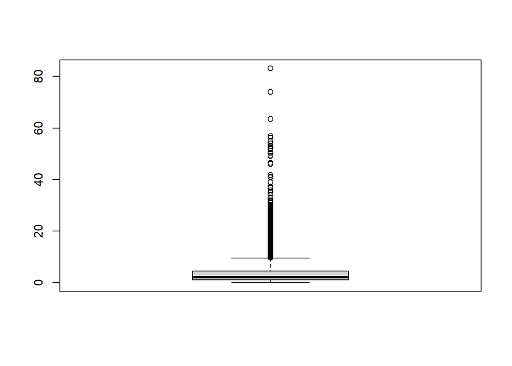

```r
# ICU los
boxplot(aldNonLT_icu$los)
```

```r
## who are those with over 40 days of ICU los?
aldNonLT_icu|>
  filter(los>40)|> #n=20
  select(subject_id, hadm_id, stay_id, los)
```

```
# A tibble: 20 × 4
   subject_id  hadm_id  stay_id   los
        <dbl>    <dbl>    <dbl> <dbl>
 1   10354450 28518599 39932818  40.9
 2   11123887 25222193 37843152  49.3
 3   11135588 22848293 34331323  52.9
 4   11148124 20672861 31916668  41.7
 5   11194776 27195361 32616796  74.0
 6   11224428 20064504 32470108  56.8
 7   11385402 20838823 32790376  56.2
 8   11888295 24549348 39893858  50.3
 9   12457358 29246116 30798752  41.0
10   12762466 20625273 32925321  52.1
11   12843115 29953104 35526043  54.0
12   13642966 23251600 39555696  46.4
13   14923562 23365149 30916660  50.6
14   14923562 23365149 38606468  83.1
15   15865848 24712843 36865949  54.9
16   16258114 22144349 38442306  40.8
17   16541253 29792366 37731486  63.5
18   17443579 28668901 32601487  51.8
19   18737633 25852011 31819040  46.0
20   19197579 26299138 31495164  49.1
```

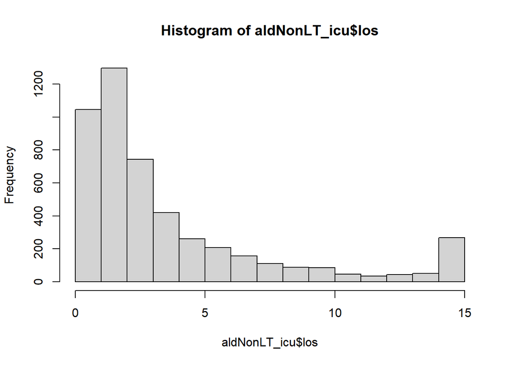

```r
## in order to improve model accuracy while preserving data integrity, we will impute the outliers with extreme values with a more reasonable value (95th percentile)
upper_95th_los <- quantile(aldNonLT_icu$los, 0.95, na.rm = TRUE) # los=14.8
aldNonLT_icu$los[aldNonLT_icu$los > upper_95th_los] <- upper_95th_los
hist(aldNonLT_icu$los) # Easier to see the distribution of ICU length of stays in one histogram
```

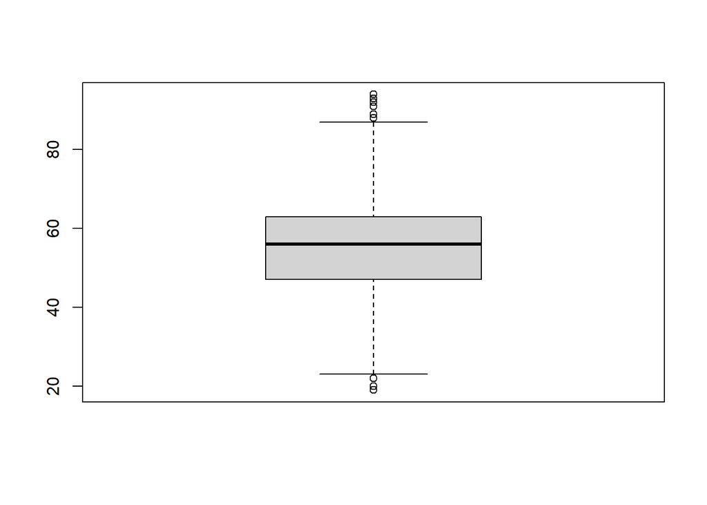

```r
# Age
boxplot(aldNonLT_icu$age)
```

```r
## FYI, MIMIC groups all patients over 89 with value 91, regardless of their real age, for de-identification purposes
aldNonLT_icu|>
  filter(age<18) #n=0
```

```
# A tibble: 0 × 87
# ℹ 87 variables: subject_id <dbl>, gender <chr>, hadm_id <dbl>, stay_id <dbl>,
#   first_careunit <chr>, last_careunit <chr>, intime <dttm>, outtime <dttm>,
#   los <dbl>, admittime <dttm>, dischtime <dttm>, admission_type <chr>,
#   admission_location <chr>, insurance <chr>, language <chr>,
#   marital_status <chr>, race <chr>, hospital_expire_flag <dbl>, age <dbl>,
#   EDlos <dbl>, EDvisit <fct>, ICUdeath <fct>, los_icu4 <fct>,
#   value_Glucose_poct <dbl>, value_RR <dbl>, value_HR <dbl>, …
```

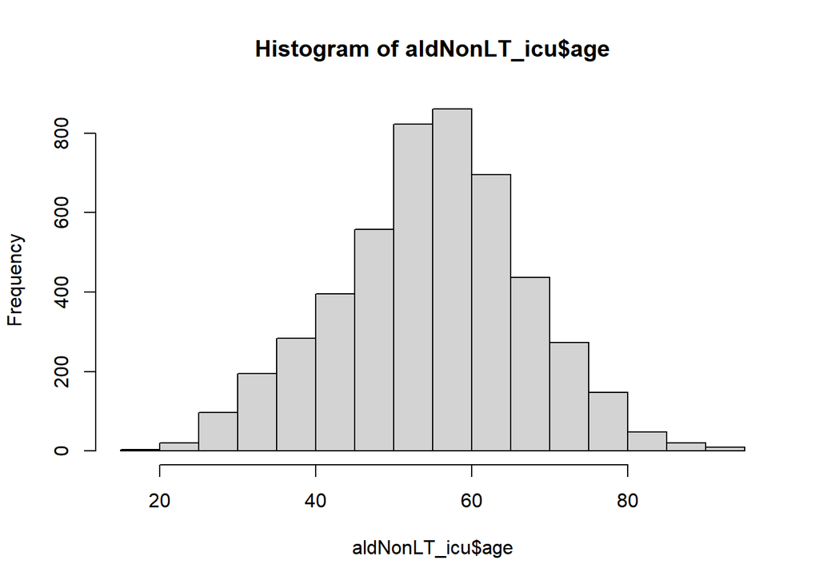

```r
hist(aldNonLT_icu$age)
```

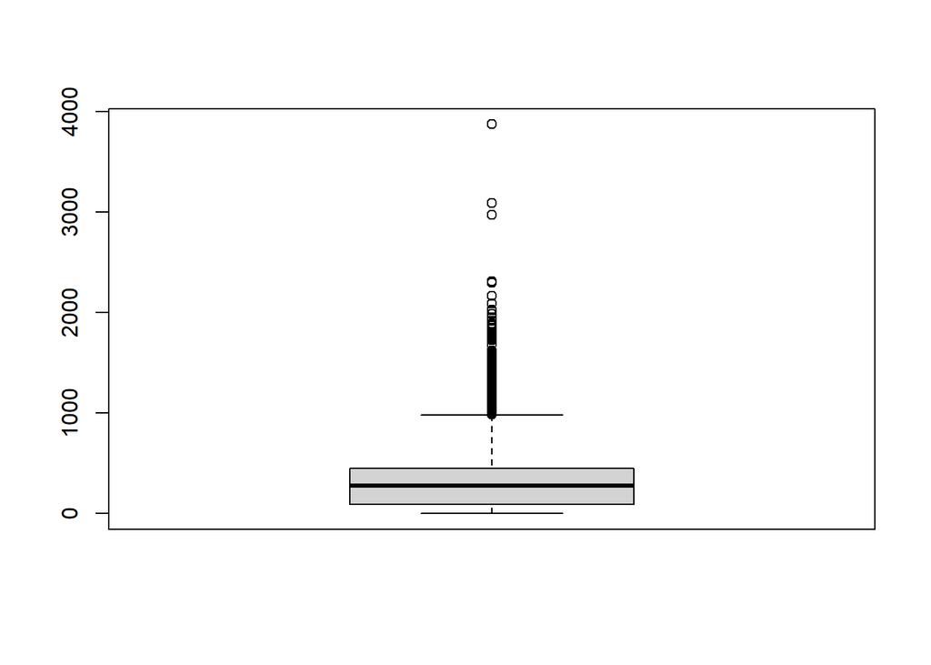

```r
# ED los
boxplot(aldNonLT_icu$EDlos, na.rm=TRUE)
```

```r
## who are those with over 24hrs of ED length of stay?
aldNonLT_icu|>
  filter(EDlos>1440, na.rm=TRUE)|> #n=78
  select(subject_id, hadm_id, stay_id, EDlos)
```

```
# A tibble: 78 × 4
   subject_id  hadm_id  stay_id EDlos
        <dbl>    <dbl>    <dbl> <dbl>
 1   10006441 24120560 37240744  1555
 2   10122346 23392196 32665794  1472
 3   10271044 25590216 31542465  1482
 4   10509845 29943903 36885223  1736
 5   11067921 29266460 37081887  1513
 6   11164952 24680477 30058643  1722
 7   11194776 25081450 38337246  2971
 8   11402251 22647855 36469596  1774
 9   11693201 22256066 37553673  1847
10   11802081 28672604 39609823  1768
# ℹ 68 more rows
```

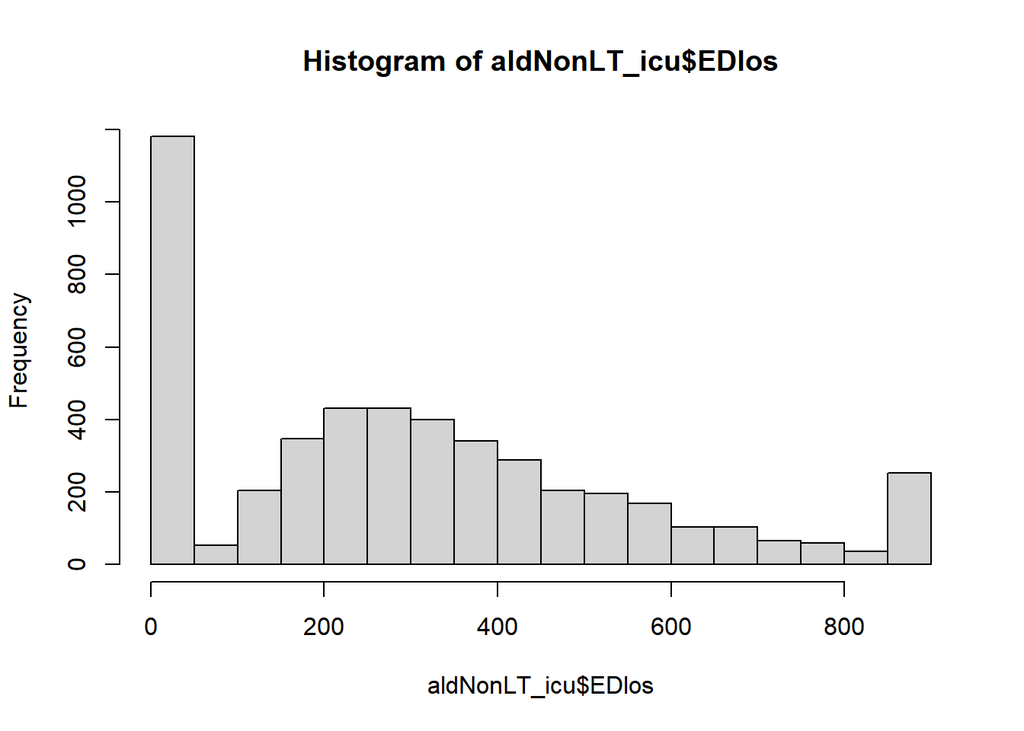

```r
## in order to improve model accuracy while preserving data integrity, we will impute the outliers with extreme values with a more reasonable value (95th percentile)
upper_95th_EDlos <- quantile(aldNonLT_icu$EDlos, 0.95, na.rm = TRUE) # EDlos= 863 minutes
aldNonLT_icu$EDlos[aldNonLT_icu$EDlos > upper_95th_EDlos] <- upper_95th_EDlos
hist(aldNonLT_icu$EDlos) # Easier to see the distribution of ED length of stays in one histogram
```

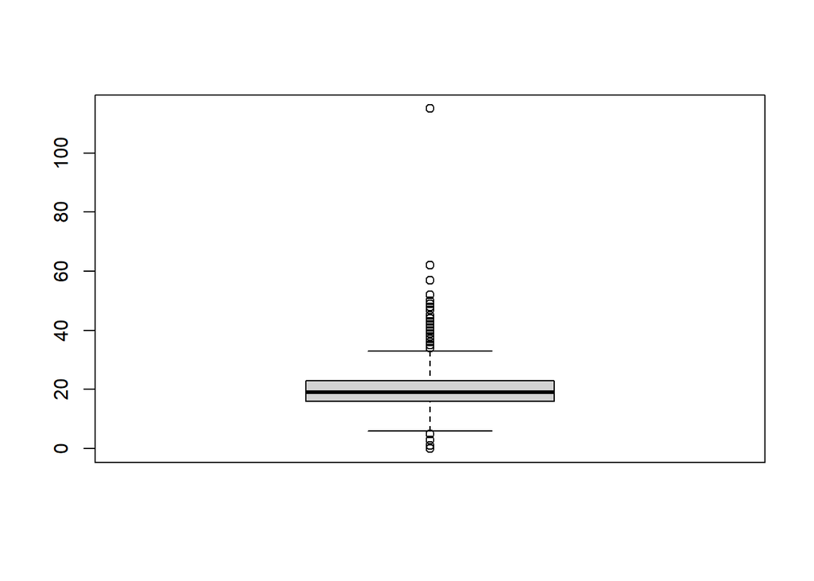

```r
# V/S: RR
boxplot(aldNonLT_icu$value_RR, na.rm=TRUE)
```

```r
## who are those with over 35 breaths/min or under 8 breaths/min?
aldNonLT_icu|>
  filter(value_RR>35)|> #n=105
  select(subject_id, hadm_id, stay_id, value_RR)
```

```
# A tibble: 105 × 4
   subject_id  hadm_id  stay_id value_RR
        <dbl>    <dbl>    <dbl>    <dbl>
 1   10072153 21253864 34751092       41
 2   10161722 23515798 37337185       44
 3   10164094 21266699 30124066       37
 4   10246670 21115828 32368059       62
 5   10284497 23736151 30848777       38
 6   10354450 29591537 35085974       39
 7   10486342 24916410 35642150       37
 8   10528589 22414279 34835242       38
 9   10623984 20233887 33513228       40
10   10677466 23769123 32421099       36
# ℹ 95 more rows
```

```r
aldNonLT_icu|>
  filter(value_RR<8)|> #n=24
  select(subject_id, hadm_id, stay_id, value_RR)
```

```
# A tibble: 24 × 4
   subject_id  hadm_id  stay_id value_RR
        <dbl>    <dbl>    <dbl>    <dbl>
 1   10809832 20695882 39219739        0
 2   11343195 21929008 38712927        0
 3   11343195 26806880 35331460        5
 4   11637705 21137019 33102129        5
 5   11789279 23757125 34998759        0
 6   12336934 27810427 34921081        0
 7   13444425 23135344 32646061        6
 8   15101183 26389834 31926891        6
 9   15949525 22830637 37326675        6
10   16536220 24609973 39500638        7
# ℹ 14 more rows
```

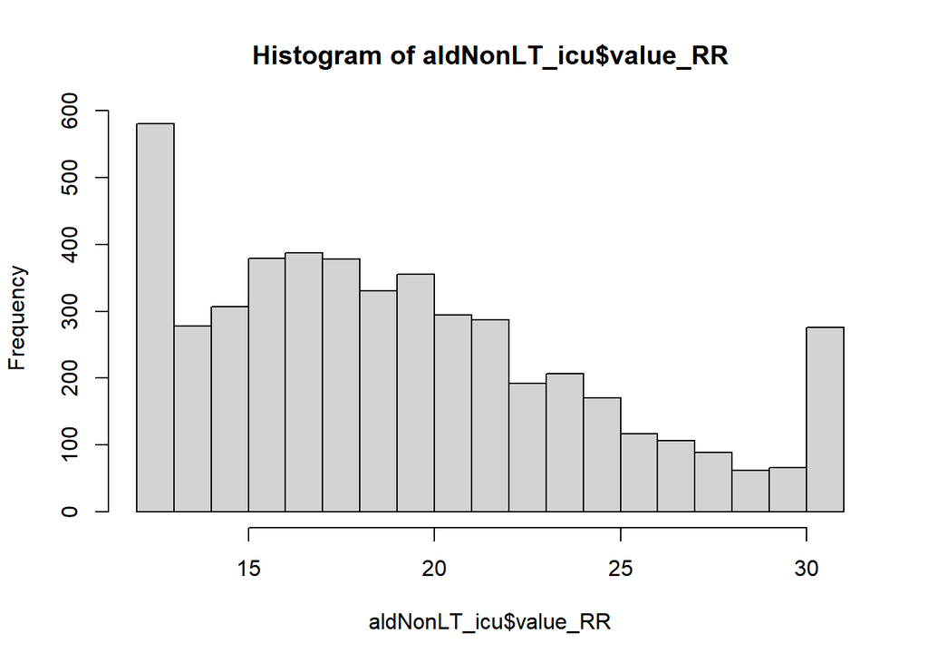

```r
## in order to improve model accuracy while preserving data integrity, we will impute the outliers with extreme values with a more reasonable value (accurate value or 5th/95th percentile)
upper_95th_RR <- quantile(aldNonLT_icu$value_RR, 0.95, na.rm = TRUE) # value_RR= 31 breaths/min
lower_5th_RR <- quantile(aldNonLT_icu$value_RR, 0.05, na.rm = TRUE) # value_RR= 12 breaths/min
aldNonLT_icu<-aldNonLT_icu|>
  mutate(value_RR= ifelse(value_RR > upper_95th_RR, upper_95th_RR, value_RR))|>
  mutate(value_RR= ifelse(value_RR < lower_5th_RR, lower_5th_RR, value_RR))
hist(aldNonLT_icu$value_RR) # Easier to see the distribution of RR in one histogram
```

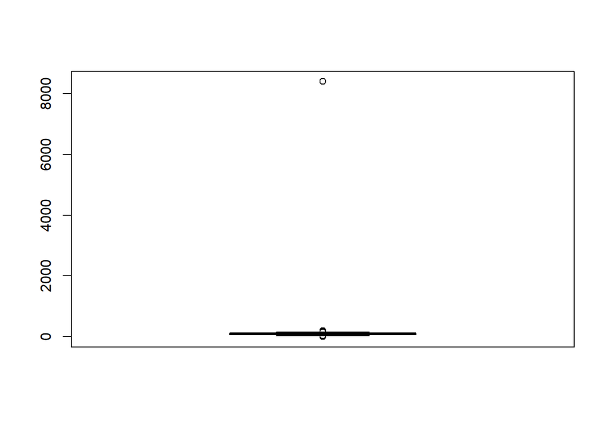

```r
# V/S: HR
boxplot(aldNonLT_icu$value_HR, na.rm=TRUE)
```

```r
## who are those with HR > 140 bpm or HR <40 bpm?
aldNonLT_icu|>
  filter(value_HR>140)|> #n=92
  select(subject_id, hadm_id, stay_id, value_HR) #10219906 has a HR of 8400 ... when referring to his other V/S, this seems to be a typo for 84
```

```
# A tibble: 92 × 4
   subject_id  hadm_id  stay_id value_HR
        <dbl>    <dbl>    <dbl>    <dbl>
 1   10122346 25026378 36597975      141
 2   10219906 26993822 33677583     8400
 3   10312652 24130729 33435189      151
 4   10398981 28167602 34166660      142
 5   10400024 29667100 32539832      158
 6   10430539 25368688 36937902      142
 7   10504898 21109438 34217611      148
 8   10623984 20782365 31686910      142
 9   10702864 23206825 31297623      160
10   10708073 23310234 33969598      162
# ℹ 82 more rows
```

```r
aldNonLT_icu|>
  filter(value_HR<40)|> #n=6
  select(subject_id, hadm_id, stay_id, value_HR) #10809832 has a HR of 0 that was reassessed 32 minutes later at 76 bpm #14858739 has a HR of 0 that was reassessed 10 minutes later at 66 bpm #the remaining subject_id+stay_id values appear correct
```

```
# A tibble: 6 × 4
  subject_id  hadm_id  stay_id value_HR
       <dbl>    <dbl>    <dbl>    <dbl>
1   10667229 21529963 31808241       39
2   10809832 20695882 39219739        0
3   13188363 24879827 34519920       38
4   13280884 26686292 34180137       33
5   14632617 29612314 36061400       38
6   14858739 22332316 37414501        0
```

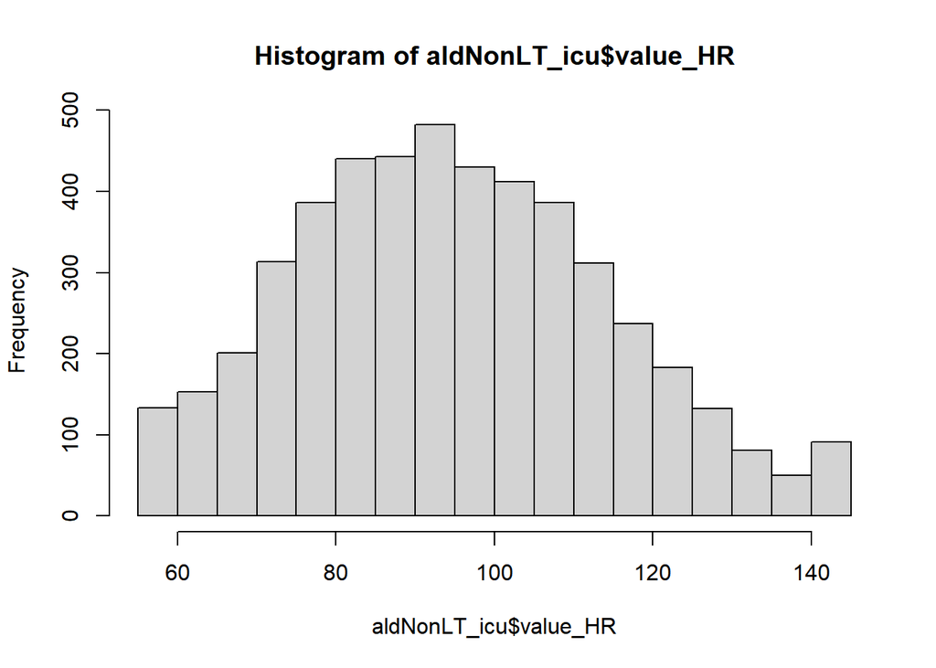

```r
## in order to improve model accuracy while preserving data integrity, we will impute the outliers with extreme values with a more reasonable value (accurate value or 5th/95th percentile)
upper_95th_HR <- quantile(aldNonLT_icu$value_HR, 0.95, na.rm = TRUE) # value_HR= 129 bpm ... but HR can rise to 140 bpm on exertion, anxiety, or cardiac dysrhythmias such as Afib
upper_99th_HR <- quantile(aldNonLT_icu$value_HR, 0.99, na.rm = TRUE) # value_HR= 145 bpm... the upper 99th percentile HR will be used as the threshold for imputation to allow for variability from normal compensatory tachycardia
lower_5th_HR <- quantile(aldNonLT_icu$value_HR, 0.05, na.rm=TRUE) # value_HR= 64 bpm ... but a normal HR value ranges from 60-100 bpm
lower_1th_HR <- quantile(aldNonLT_icu$value_HR, 0.01, na.rm=TRUE) # value_HR= 55 bpm ... the lower 1st percentile HR will be used to accommodate normal physiological variations among individuals without flagging too many false alerts
aldNonLT_icu <- aldNonLT_icu %>%
  mutate(value_HR = ifelse(value_HR == 8400 & subject_id==10219906 & hadm_id == 26993822 & stay_id==33677583, 84, value_HR))|>
  mutate(value_HR = ifelse(value_HR == 0 & subject_id==10809832 & hadm_id == 20695882 & stay_id==39219739, 76, value_HR))|>
  mutate(value_HR = ifelse(value_HR == 0 & subject_id==14858739 & hadm_id == 22332316 & stay_id==37414501, 66, value_HR))|>
  mutate(value_HR = ifelse(value_HR > upper_99th_HR, upper_99th_HR, value_HR))|>
  mutate(value_HR = ifelse(value_HR < lower_1th_HR, lower_1th_HR, value_HR))
hist(aldNonLT_icu$value_HR) # Easier to see the distribution of HR in one histogram
```

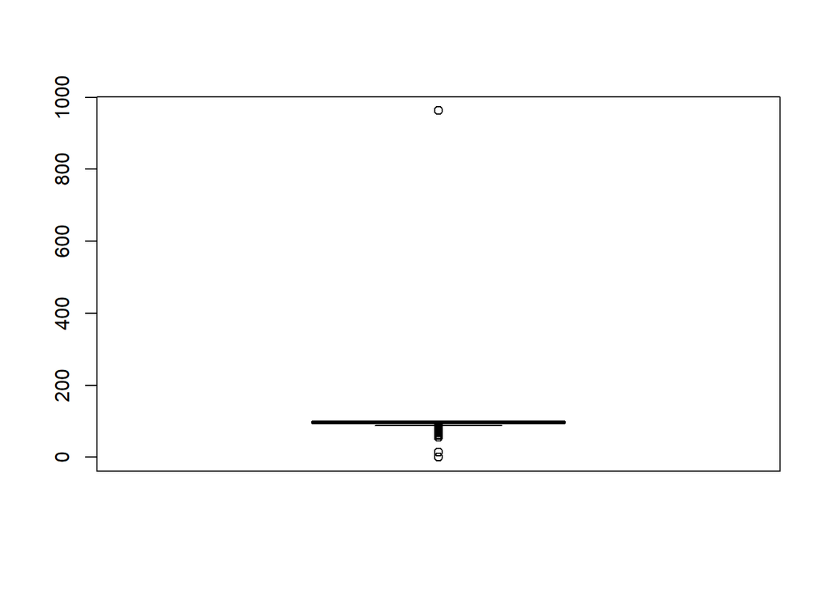

```r
# V/S: SpO2
boxplot(aldNonLT_icu$value_SpO2, na.rm=TRUE)
```

```r
## who are those with SpO2 > 100% or SpO2 <80%?
aldNonLT_icu|>
  filter(value_SpO2>100)|> #n=1
  select(subject_id, hadm_id, stay_id, value_SpO2) #18353640 has a SpO2 of 963% ... when referring to abga results, this seems to be a typo for 96%
```

```
# A tibble: 1 × 4
  subject_id  hadm_id  stay_id value_SpO2
       <dbl>    <dbl>    <dbl>      <dbl>
1   18353640 21455850 35801109        963
```

```r
aldNonLT_icu|>
  filter(value_SpO2<80)|> #n=20
  select(subject_id, hadm_id, stay_id, value_SpO2) #14086229 has a SpO2 of 0% ... when referring to other v/s and ICU prognosis (death at ICU on the day after admission) it seems like it would have been low
```

```
# A tibble: 20 × 4
   subject_id  hadm_id  stay_id value_SpO2
        <dbl>    <dbl>    <dbl>      <dbl>
 1   10667229 21529963 31808241         71
 2   10887646 25719925 37802486         77
 3   11402910 23375177 36422142         78
 4   12755163 27476550 38068845         56
 5   13060513 23186507 35295689         76
 6   13475074 26619417 35068838         75
 7   14004449 26878410 38494981         68
 8   14083975 26931449 31861090         74
 9   14086229 28725788 37924209          0
10   14209622 25064955 39551809         76
11   14672004 21316169 39722585         70
12   16256079 26960609 36419553         69
13   16460365 25574326 35945052         73
14   17668166 28211793 35509240         14
15   17963447 21920952 33128057         72
16   19157548 21822936 31306016         60
17   19757064 21770430 34204033         60
18   19774838 28109956 39992578         76
19   19937374 29175646 36709438         67
20   19959862 22780970 30956134         62
```

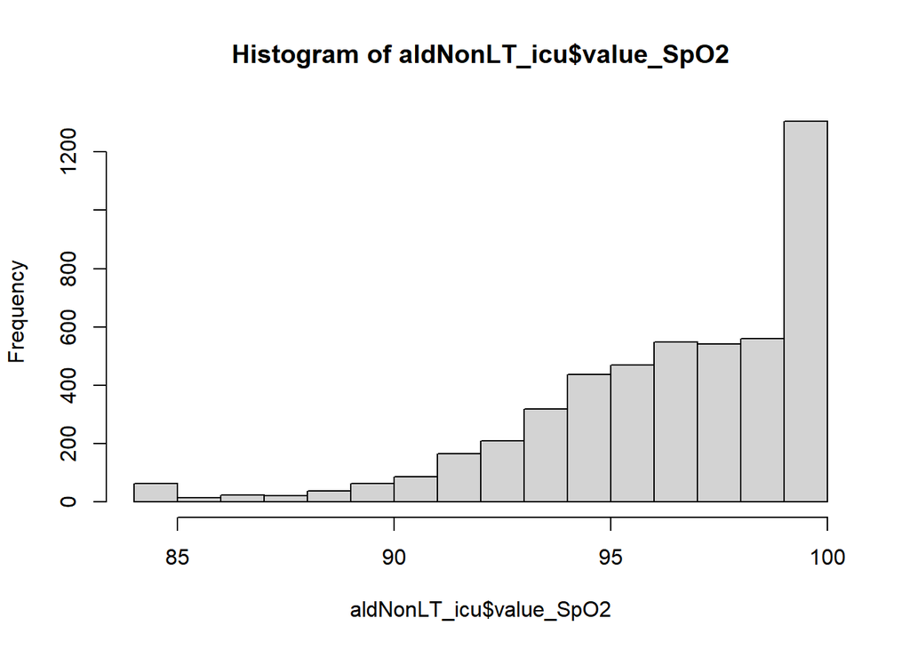

```r
## in order to improve model accuracy while preserving data integrity, we will impute the outliers with extreme values with a more reasonable value (accurate value or 5th/95th percentile)
lower_5th_SpO2 <- quantile(aldNonLT_icu$value_SpO2, 0.05, na.rm = TRUE) # value_SpO2= 91% ... however, imputing using this measure would not be able to distinguish between mild and severe hypoxemia, as shown in the oxygen-hemoglobin dissociation curve
lower_1th_SpO2 <- quantile(aldNonLT_icu$value_SpO2, 0.01, na.rm = TRUE) # value_SpO2= 84% ... this better accounts for the nonlinear relationship between oxygen saturation and PaO2
aldNonLT_icu <- aldNonLT_icu %>%
  mutate(value_SpO2 = ifelse(value_SpO2 == 963 & subject_id==18353640  & hadm_id == 21455850  & stay_id==35801109, 96, value_SpO2))|>
  mutate(value_SpO2 = ifelse(value_SpO2<lower_1th_SpO2, lower_1th_SpO2, value_SpO2))
hist(aldNonLT_icu$value_SpO2) # Easier to see the distribution of SpO2 in one histogram
```

```r
# V/S: NIBPm
range(aldNonLT_icu$value_NIBPm, na.rm = TRUE)
```

```
[1]    8 6116
```

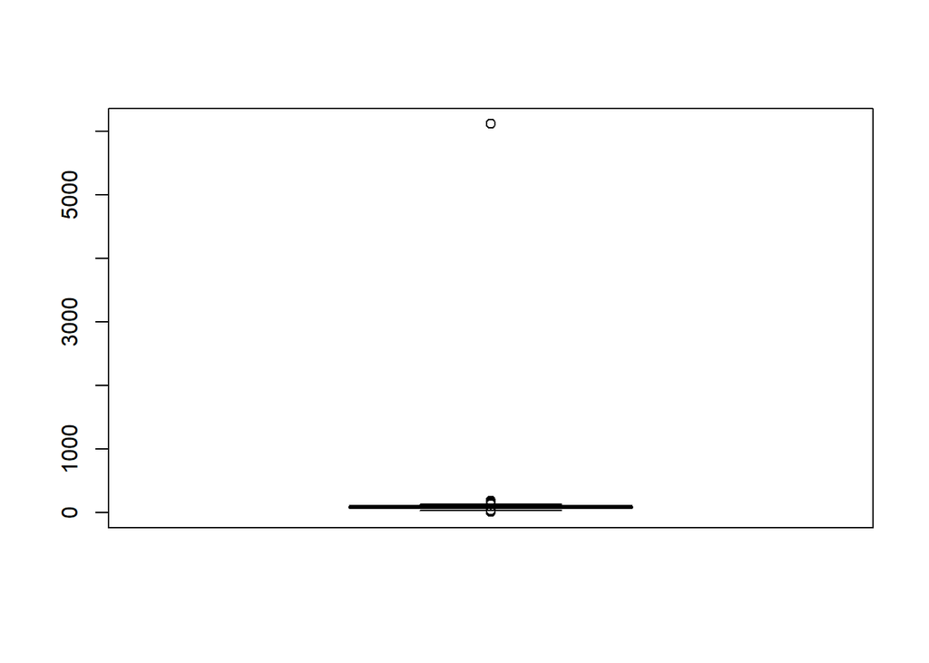

```r
boxplot(aldNonLT_icu$value_NIBPm, na.rm=TRUE)
```

```r
## who are those with NIBPm > 140 mmHg or NIBPm < 30 mmHg?
aldNonLT_icu|>
  filter(value_NIBPm>140)|> #n=28
  select(subject_id, hadm_id, stay_id, value_NIBPm) #19063358 has a NIBPm=6116 which was measured 15 minutes later at 69 mmHg
```

```
# A tibble: 28 × 4
   subject_id  hadm_id  stay_id value_NIBPm
        <dbl>    <dbl>    <dbl>       <dbl>
 1   10138206 29096936 33712680         161
 2   10504898 21109438 34217611         162
 3   10730662 23676947 35813232         143
 4   10749008 29317137 31431413         165
 5   10812044 25241879 30847475         154
 6   10860466 29664840 32364300         186
 7   11194776 27195361 34149316         156
 8   12021129 22248492 35032965         145
 9   12489419 20908680 39843122         150
10   12553113 21570112 33997173         146
# ℹ 18 more rows
```